# Final version - HW8 - mw5599

```python
import pandas as pd
import numpy as np
s = '/Users/morganwaddington/Documents/Tandon/Classes/Machine-Learning/datasets/SeoulBikeData(in).csv'
df = pd.read_csv(s, encoding='ISO-8859-1')
```

```python
from IPython.display import display, HTML
display(HTML(f"<h2>Features that I think may be correlated to each other: </h2>"))
```

Features that I think may be correlated to each other:

I tried taking 6 different features to diversify the analysis.

Temperature Vs Dew Point: The dew point is the temperature at which air becomes so full of moisture that it starts to release it as liquid. It’s tied to how humid the air is. When the air warms up, it can hold more moisture, so the dew point often goes up too.

Humidity vs Rainfall: Both metrics should be correlated as they are typically engaged in a feedback loop with each other. On one had if it rains, more moisture will be released into the air. On the other, hight water content in the air makes it more likely to rain.

Snowfall vs Solar Radiation: Snowfall usually only occurs when days are short and skies are overcast, which means there’s less sunlight and, therefore, less solar radiation.

Scatter plots of features I think are correlated:

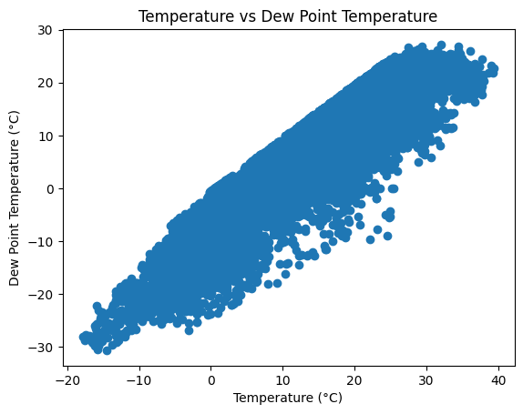

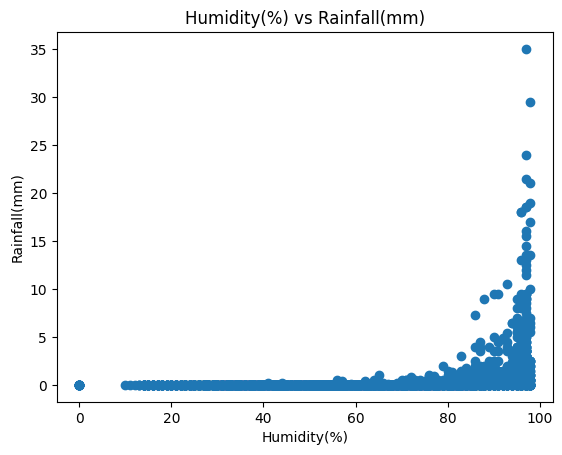

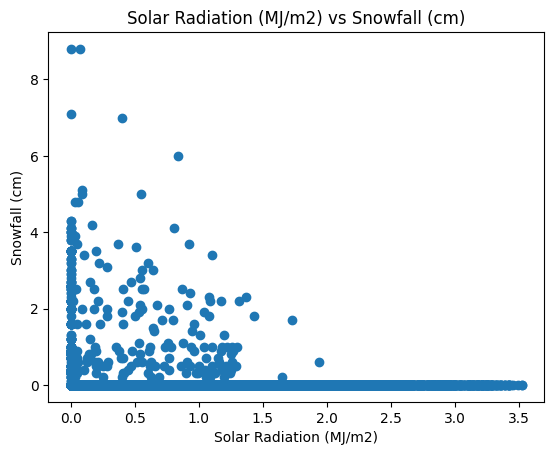

```python
import matplotlib.pyplot as plt

display(HTML(f"<h2>Scatter plots of features I think are correlated:</h2>"))

plt.scatter(df['Temperature(°C)'], df['Dew point temperature(°C)'])
plt.xlabel('Temperature (°C)')
plt.ylabel('Dew Point Temperature (°C)')
plt.title('Temperature vs Dew Point Temperature')
plt.show()


plt.scatter(df['Humidity(%)'], df['Rainfall(mm)'])
plt.xlabel('Humidity(%)')
plt.ylabel('Rainfall(mm)')
plt.title('Humidity(%) vs Rainfall(mm)')
plt.show()


plt.scatter(df['Solar Radiation (MJ/m2)'], df['Snowfall (cm)'])
plt.xlabel('Solar Radiation (MJ/m2)')
plt.ylabel('Snowfall (cm)')
plt.title('Solar Radiation (MJ/m2) vs Snowfall (cm)')
plt.show()
```

As expected, dew point and temperature are highly positively correlated. For rainfall and humidity, we observe that humidity can vary widely when there’s no rain. However, once rainfall appears, humidity is never below 40% and can increase almost exponentially as rainfall rises, suggesting rain is just one of several factors affecting humidity levels. Lastly, we see that solar radiation is not very correlated to snow and can vary widely when there’s none of the latter. We can slightly see throught the plot that the more snow there is, the lower the radiation levels but it is certainly not as apparent as the first plot.

```python
display(HTML(f"<h2>Features that I think may be correlated to the rented bike count: </h2>"))
```

Features that I think may be correlated to the rented bike count:

Temperatures: Warmer temperatures likely encourage more bike rentals, though there may be an upper limit where extreme heat deters riders.

Rainfall: Rain isn’t ideal for biking, so I expect bike demand to decrease as rainfall increases.

Snowfall: Similar to rain, more snow means less bike rentals. People generally avoid biking in snowy conditions unless necessary.

Scatter plots of features I think are correlated:

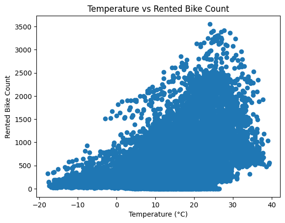

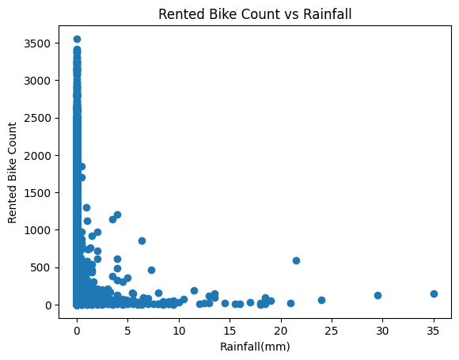

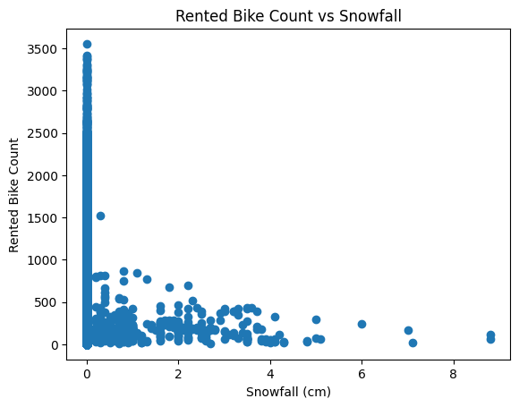

```python
display(HTML(f"<h2>Scatter plots of features I think are correlated:</h2>"))

plt.scatter(df['Temperature(°C)'], df['Rented Bike Count'])
plt.xlabel('Temperature (°C)')
plt.ylabel('Rented Bike Count')
plt.title('Temperature vs Rented Bike Count')
plt.show()


plt.scatter(df['Rainfall(mm)'],df['Rented Bike Count'])
plt.xlabel('Rainfall(mm)')
plt.ylabel('Rented Bike Count')
plt.title('Rented Bike Count vs Rainfall')
plt.show()


plt.scatter(df['Snowfall (cm)'], df['Rented Bike Count'], )
plt.xlabel('Snowfall (cm)')
plt.ylabel('Rented Bike Count')
plt.title('Rented Bike Count vs Snowfall')
plt.show()
```

As anticipated, bike demand is at its lowest when temperatures approach -20°C. The upper limit of bike rentals consistently rises as the temperature increases. Correlation index of .54

Less correlated than I expected. When there is no rain demand for bikes is completly variable. Once rain appears, the maximum rentals cap at around 2000 and generally decrease with higher rain levels, often staying close to zero. Correlation index of -.12

```python
df = pd.get_dummies(df, columns=['Seasons', 'Holiday', 'Functioning Day'])
```

Correlation matrix:

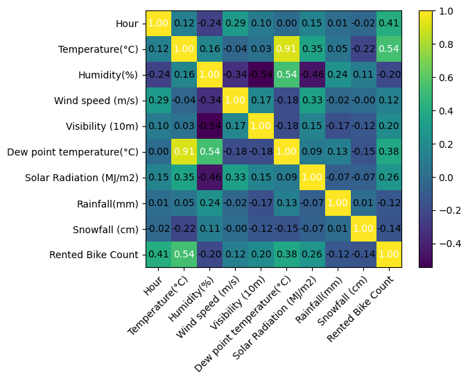

```python
from mlxtend.plotting import heatmap
display(HTML(f"<h2>Correlation matrix:</h2>"))
cm = np.corrcoef(df[cols].values.T)
hm = heatmap(cm,
              row_names=cols,
              column_names=cols)
plt.show()
```

```python
y = df['Rented Bike Count'].values
df = df.drop('Date', axis=1)
df = df.drop('Rented Bike Count', axis=1)
X = df.values
```

```python
from sklearn.model_selection import train_test_split
X_train, X_test, y_train, y_test = train_test_split(X, y, test_size=0.4, random_state=1)
X_val, X_test, y_val, y_test = train_test_split(X_test, y_test, test_size=0.5, random_state=1)
```

```python
from sklearn.linear_model import LinearRegression
from IPython.display import display, HTML

display(HTML(f"<h1>Applying Linear regression and Random Forest regression methods</h1>"))
display(HTML(f"<h2>Linear regression results:</h2>"))


slr = LinearRegression()
slr.fit(X_train, y_train)
y_train_pred = slr.predict(X_train)
y_val_pred = slr.predict(X_val)
y_test_pred = slr.predict(X_test)
print('MSE TRAIN: %.2f,\tVALIDATE: %.2f,\tTEST: %.2f' % (
    mean_squared_error(y_train, y_train_pred),
    mean_squared_error(y_val, y_val_pred),
    mean_squared_error(y_test, y_test_pred)))
print('R2 TRAIN: %.2f,\t\tVALIDATE: %.2f,\t\tTEST: %.2f' % (
    r2_score(y_train, y_train_pred),
    r2_score(y_val, y_val_pred),
    r2_score(y_test, y_test_pred)))

display(HTML(f"<h2>Random Forest results:</h2>"))

from sklearn.ensemble import RandomForestRegressor
forest = RandomForestRegressor(n_estimators=100, criterion='friedman_mse', random_state=1, n_jobs=-1)

forest.fit(X_train, y_train)
y_train_pred = forest.predict(X_train)
y_val_pred = forest.predict(X_val)
y_test_pred = forest.predict(X_test)
print('MSE TRAIN: %.2f,\tVALIDATE: %.2f,\tTEST: %.2f' % (
    mean_squared_error(y_train, y_train_pred),
    mean_squared_error(y_val, y_val_pred),
    mean_squared_error(y_test, y_test_pred)))
print('R2 TRAIN: %.2f,\t\tVALIDATE: %.2f,\t\tTEST: %.2f' % (
    r2_score(y_train, y_train_pred),
    r2_score(y_val, y_val_pred),
    r2_score(y_test, y_test_pred)))
```

Applying Linear regression and Random Forest regression methods

Linear regression results:

```
MSE TRAIN: 187417.56,	VALIDATE: 188002.79,	TEST: 186120.40
R2 TRAIN: 0.55,		VALIDATE: 0.55,		TEST: 0.54
```

Random Forest results:

```
MSE TRAIN: 7508.54,	VALIDATE: 54509.82,	TEST: 56983.87
R2 TRAIN: 0.98,		VALIDATE: 0.87,		TEST: 0.86
```

The results for linear regression are pretty poor for the test data, scoring 0.54 as an R2 score. This means only 54% of the variations in the demande can be explained by the model and it's features. The linear regression model relies on the assumption that there is a linear relationship between the independent features and the rented bike count. In our dataset, only temperature and hour have moderate linear correlations with bike demand, with correlation coefficients of 0.54 and 0.41, respectively. All other features exhibit relatively low linear correlations with the target variable. This means that most features do not contribute significantly to the model's predictive power in a linear context. As a result, the model struggles to accurately predict the bike demand because it cannot capture the underlying patterns effectively with linear relationships alone. The Random Forest model did much better on the test data, with an R2 score of 0.86. This means it can explain 86% of the changes in bike demand based on the features we used. There is some level of overfitting as seen in the increase in MSE compared to the training data but overall the resuls are still good. As stated before, in this dataset, we can't pull out meaningful preditions by just plotting a line through the data. Fortunately Random Forest builds multiple decision trees and can thus "see" more links between the features. Therefore it makes much better prediction an the mean square average is 3x smaller than in linear regression.